# Lab 5

## Set-up and Question 4

** These homework’s are getting harder and harder and are taking away more and more time from my other classes. I think that number 3 took me around 4 hours and I felt like I got no where.

```r
library(dplyr)
library(tidyverse)
library(lubridate)
```

```r
library(ggplot2)
library(readxl)
library(ggrepel)
library(ggthemes)

acc <- read.csv("https://raw.githubusercontent.com/xdaiISU/ds202materials/master/hwlabs/fars2017/accident.csv", stringsAsFactors = FALSE)
per <- read.csv("https://raw.githubusercontent.com/xdaiISU/ds202materials/master/hwlabs/fars2017/person.csv", stringsAsFactors = FALSE)
GLC <- read_xlsx("C:\\Users\\samue\\OneDrive\\Documents\\ds202_lab5\\GLC.xlsx")
df <-acc %>%
  inner_join(per, by = "ST_CASE")

#str(df)
GLC$`State Code` <- as.integer(GLC$`State Code`)
GLC$`County Code` <- as.integer(GLC$`County Code`)
str(GLC)
```

```
## tibble [39,735 x 11] (S3: tbl_df/tbl/data.frame)
##  $ Territory        : chr [1:39735] "U" "U" "U" "U" ...
##  $ State Name       : chr [1:39735] "ALABAMA" "ALABAMA" "ALABAMA" "ALABAMA" ...
##  $ State Code       : int [1:39735] 1 1 1 1 1 1 1 1 1 1 ...
##  $ City Code        : chr [1:39735] "10" "50" "60" "0070" ...
##  $ City Name        : chr [1:39735] "ABBEVILLE" "ALBERTVILLE" "ALEXANDER CITY" "ALICEVILLE" ...
##  $ County Code      : int [1:39735] 67 95 123 107 39 77 15 15 109 95 ...
##  $ County Name      : chr [1:39735] "HENRY" "MARSHALL" "TALLAPOOSA" "PICKENS" ...
##  $ Country Code     : chr [1:39735] "840" "840" "840" "840" ...
##  $ Old City Name    : chr [1:39735] NA NA NA NA ...
##  $ Date Record Added: logi [1:39735] NA NA NA NA NA NA ...
##  $ Duty Station Code: chr [1:39735] "010010067" "010050095" "010060123" "010070107" ...
```

## Question 1

Create a data frame containing the persons who are fatally hurt in the accidents (see FARS manual and look up variable INJ_SEV)

```r
df1 <- df[df$INJ_SEV ==4,]

str(df1)
```

```
## 'data.frame':    37133 obs. of  119 variables:
##  $ STATE.x   : int  1 1 1 1 1 1 1 1 1 1 ...
##  $ ST_CASE   : int  10001 10002 10003 10004 10005 10006 10007 10008 10009 10010 ...
##  $ VE_TOTAL  : int  1 1 3 1 1 2 2 1 1 1 ...
##  $ VE_FORMS.x: int  1 1 3 1 1 2 2 1 1 1 ...
##  $ PVH_INVL  : int  0 0 0 0 0 0 0 0 0 0 ...
##  $ PEDS      : int  0 0 0 0 0 0 0 0 0 1 ...
##  $ PERNOTMVIT: int  0 0 0 0 0 0 0 0 0 1 ...
##  $ PERMVIT   : int  1 1 3 1 2 4 2 1 1 1 ...
##  $ PERSONS   : int  1 1 3 1 2 4 2 1 1 1 ...
##  $ COUNTY.x  : int  73 89 101 73 13 49 73 3 87 73 ...
##  $ CITY      : int  330 1730 2130 350 0 0 350 0 0 0 ...
##  $ DAY.x     : int  19 14 31 1 1 6 11 11 11 14 ...
##  $ MONTH.x   : int  2 2 1 1 1 1 1 1 1 1 ...
##  $ YEAR      : int  2017 2017 2017 2017 2017 2017 2017 2017 2017 2017 ...
```

[output cut: 86 more lines]

## Question 2

Create a data frame containing the most dangerous vehicle make in each state. The number of persons fatally hit in the vehicle make is used to assess the (non-)safety of a make. Make sure to handle the missing values appropriately. (look up variable MAKE)

```r
df2 <- df1 %>%
  group_by(STATE.x, MAKE) %>%
  summarise(count = n()) %>%
  drop_na(MAKE)
df2
```

```
## # A tibble: 1,974 x 3
## # Groups:   STATE.x [51]
##    STATE.x  MAKE count
##      <int> <int> <int>
##  1       1     2    30
##  2       1     3     3
##  3       1     6    10
##  4       1     7    42
##  5       1     9     2
##  6       1    12   138
##  7       1    13     5
##  8       1    14    12
##  9       1    18    18
## 10       1    19     7
## # ... with 1,964 more rows
```

```r
df3 <- df2 %>%
  group_by(STATE.x) %>%
  filter(count == max(count))

df3
```

```
## # A tibble: 54 x 3
## # Groups:   STATE.x [51]
##    STATE.x  MAKE count
##      <int> <int> <int>
##  1       1    12   138
##  2       2    12     9
##  3       4    20    88
##  4       5    20    88
##  5       6    49   351
##  6       8    12    63
##  7       8    37    63
##  8       9    37    28
##  9      10    37    12
## 10      11    37     5
## # ... with 44 more rows
```

```r
df14 <- df1 %>%
  group_by(STATE.x) %>%
  summarise(LAT = mean(LATITUDE), LON = mean(LONGITUD))%>%
  drop_na

df14
```

```
## # A tibble: 51 x 3
##    STATE.x   LAT     LON
##      <int> <dbl>   <dbl>
##  1       1  33.1  -85.6
##  2       2  62.6 -136.
##  3       4  40.4    1.59
##  4       5  35.1  -92.5
##  5       6  35.9 -119.
##  6       8  39.5 -105.
##  7       9  41.9  -65.1
##  8      10  39.2  -75.5
##  9      11  38.9  -77.0
## 10      12  28.2  -81.1
## # ... with 41 more rows
```

## Question 3

Create a map, and label each state with the most dangerous vehicle. Discuss the definition of the most dangerous vehicle, and what you find from the map. (Hint: Read the description for the STATE and COUNTY columns in the FARS manual. The state & county codes are Geographic Locator Codes (GLCs) from the General Services Administration’s (GSA) publication. Use readxl::read_xlsx to read in the GLCs.)

```r
GLC1 <- GLC %>%
  select(`State Code`, `State Name`) %>%
  distinct(`State Code`, `State Name`) %>%
  rename(STATE = `State Name`)%>%
  rename(STATE.x = `State Code`)

GLC1$region <- tolower(GLC1$STATE)

GLC1
```

```
## # A tibble: 51 x 3
##    STATE.x STATE                region
##      <int> <chr>                <chr>
##  1       1 ALABAMA              alabama
##  2       2 ALASKA               alaska
##  3       4 ARIZONA              arizona
##  4       5 ARKANSAS             arkansas
##  5       6 CALIFORNIA           california
##  6       8 COLORADO             colorado
##  7       9 CONNECTICUT          connecticut
##  8      10 DELAWARE             delaware
##  9      11 DISTRICT OF COLUMBIA district of columbia
## 10      12 FLORIDA              florida
## # ... with 41 more rows
```

```r
joined1 <- inner_join(GLC1, df3, by = 'STATE.x')
joined1
```

```
## # A tibble: 54 x 5
##    STATE.x STATE                region                MAKE count
##      <int> <chr>                <chr>                <int> <int>
##  1       1 ALABAMA              alabama                 12   138
##  2       2 ALASKA               alaska                  12     9
##  3       4 ARIZONA              arizona                 20    88
##  4       5 ARKANSAS             arkansas                20    88
##  5       6 CALIFORNIA           california              49   351
##  6       8 COLORADO             colorado                12    63
##  7       8 COLORADO             colorado                37    63
##  8       9 CONNECTICUT          connecticut             37    28
##  9      10 DELAWARE             delaware                37    12
## 10      11 DISTRICT OF COLUMBIA district of columbia    37     5
## # ... with 44 more rows
```

```r
states <- map_data('state')
str(states)
```

```
## 'data.frame':    15537 obs. of  6 variables:
##  $ long     : num  -87.5 -87.5 -87.5 -87.5 -87.6 ...
##  $ lat      : num  30.4 30.4 30.4 30.3 30.3 ...
##  $ group    : num  1 1 1 1 1 1 1 1 1 1 ...
##  $ order    : int  1 2 3 4 5 6 7 8 9 10 ...
##  $ region   : chr  "alabama" "alabama" "alabama" "alabama" ...
##  $ subregion: chr  NA NA NA NA ...
```

```r
joined2 <- inner_join(joined1, states, by = 'region')
joined2
```

```
## # A tibble: 15,950 x 10
##    STATE.x STATE   region   MAKE count  long   lat group order subregion
##      <int> <chr>   <chr>   <int> <int> <dbl> <dbl> <dbl> <int> <chr>
##  1       1 ALABAMA alabama    12   138 -87.5  30.4     1     1 <NA>
##  2       1 ALABAMA alabama    12   138 -87.5  30.4     1     2 <NA>
##  3       1 ALABAMA alabama    12   138 -87.5  30.4     1     3 <NA>
##  4       1 ALABAMA alabama    12   138 -87.5  30.3     1     4 <NA>
##  5       1 ALABAMA alabama    12   138 -87.6  30.3     1     5 <NA>
##  6       1 ALABAMA alabama    12   138 -87.6  30.3     1     6 <NA>
##  7       1 ALABAMA alabama    12   138 -87.6  30.3     1     7 <NA>
##  8       1 ALABAMA alabama    12   138 -87.6  30.3     1     8 <NA>
##  9       1 ALABAMA alabama    12   138 -87.7  30.3     1     9 <NA>
## 10       1 ALABAMA alabama    12   138 -87.8  30.3     1    10 <NA>
## # ... with 15,940 more rows
```

```r
anti_join(states,joined1)
```

```
## [1] long      lat       group     order     region    subregion
## <0 rows> (or 0-length row.names)
```

```r
joined6 <- inner_join(df14, df2, by = 'STATE.x')

joined6 <- joined6 %>%
  group_by(STATE.x) %>%
  filter(count == max(count))

joined6
```

```
## # A tibble: 54 x 5
## # Groups:   STATE.x [51]
##    STATE.x   LAT     LON  MAKE count
##      <int> <dbl>   <dbl> <int> <int>
##  1       1  33.1  -85.6     12   138
##  2       2  62.6 -136.      12     9
##  3       4  40.4    1.59    20    88
##  4       5  35.1  -92.5     20    88
##  5       6  35.9 -119.      49   351
##  6       8  39.5 -105.      12    63
##  7       8  39.5 -105.      37    63
##  8       9  41.9  -65.1     37    28
##  9      10  39.2  -75.5     37    12
## 10      11  38.9  -77.0     37     5
## # ... with 44 more rows
```

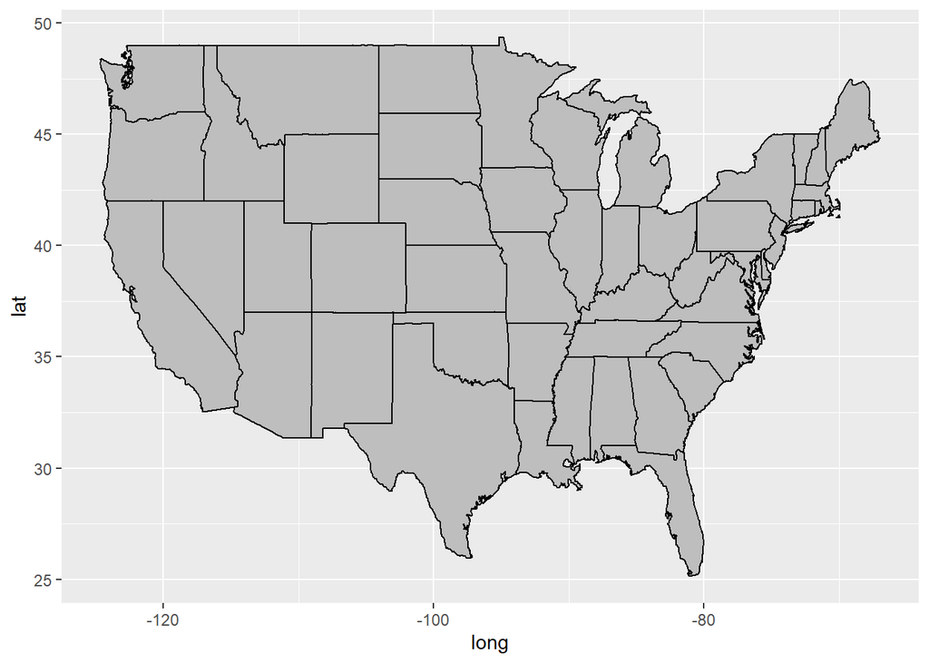

```r
stateName <- states %>%
  group_by(region) %>%
  summarize(long = mean(long), lat = mean(lat))

s <- ggplot(states, aes(x=long, y=lat,group=group))+geom_polygon(color = "black", fill = "gray")


#I know that it has to be something along the lines of this to put it in the map, but I was unable to figure it out.I was at least able to get all of the numbers and get the map plot up.#
#s <- ggplot(states, aes(x=long, y=lat,group=group))+geom_polygon(color = "black", fill = "gray")+
  #geom_text(data=joined6, aes(LON,LAT,label='MAKE'), color = 'black', injerit.aes = FALSE)

s
```

## Question 5

Tally the number of accidents by day of the week (DAY_WEEK), hour of the day (HOUR) and gender (SEX). Visualize the results and explain what you find.

### What I learned was that Friday, Saturday, and Sunday (or the weekend) is the largest time for accidents. During the home rush hour is the highest probability of getting in an accident (about 4-8pm). Statistically speaking, Males getting about double the accidents as Females.

*Day 1: Sunday* *Day 2: Monday* *Day 3: Tuesday* *Day 4: Wednesday* *Day 5: Thursday* *Day 6: Friday* *Day 7: Saturday*

```r
df4 <- df %>%
  group_by(DAY_WEEK) %>%
  summarise(count = n())

df4
```

```
## # A tibble: 7 x 2
##   DAY_WEEK count
##      <int> <int>
## 1        1 13360
## 2        2 10671
## 3        3 10571
## 4        4 10464
## 5        5 11311
## 6        6 13634
## 7        7 14910
```

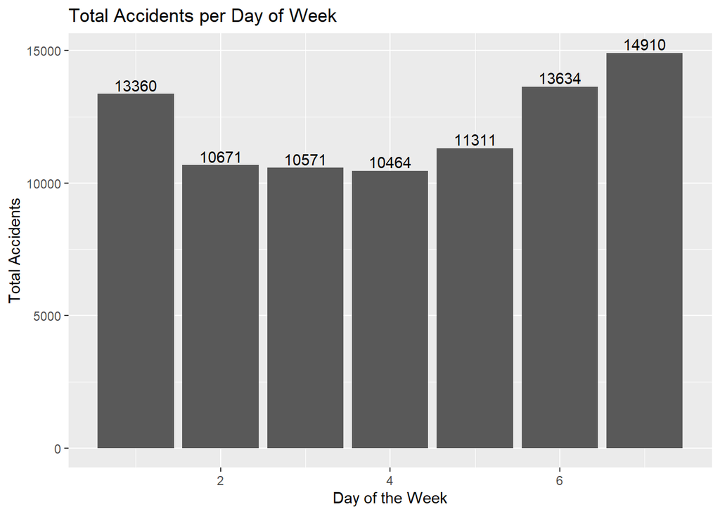

```r
p <- ggplot(df4, aes(x=DAY_WEEK, y = count)) + geom_bar(stat="identity")+geom_text(aes(label = count), position = position_dodge(width = 0.9), vjust=-0.25)
p + ggtitle("Total Accidents per Day of Week")+ylab("Total Accidents")+xlab("Day of the Week")
```

*Hour of the Day is given in military time* *There were 408 accidents that happened at an unknown time(number 99). This has been removed from the data*

```r
df5 <- df %>%
  group_by(HOUR.x) %>%
  summarise(count = n()) %>%
  filter(!row_number() %in% c(25))

df5
```

```
## # A tibble: 24 x 2
##    HOUR.x count
##     <int> <int>
##  1      0  2928
##  2      1  2540
##  3      2  2735
##  4      3  2096
##  5      4  1706
##  6      5  2269
##  7      6  2880
##  8      7  2824
##  9      8  2183
## 10      9  2301
## # ... with 14 more rows
```

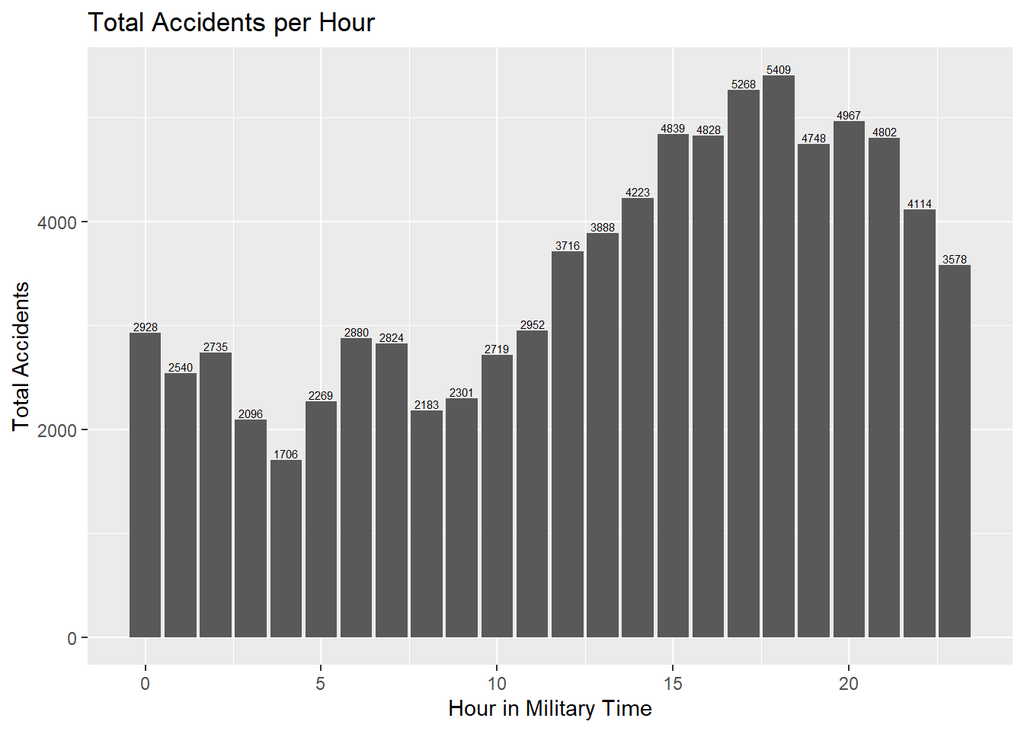

```r
p <- ggplot(df5, aes(x=HOUR.x, y = count)) + geom_bar(stat="identity")+geom_text(aes(label = count), position = position_dodge(width = 0.9), vjust=-0.25, size = 2)
p + ggtitle("Total Accidents per Hour")+ylab("Total Accidents")+xlab("Hour in Military Time")
```

*Sex 1: Male* *Sex 2: Female* *Sex 8: Not Reported* *Sex 9: Unknown*

```r
df6 <- df %>%
  group_by(SEX) %>%
  summarise(count = n())

df6
```

```
## # A tibble: 4 x 2
##     SEX count
##   <int> <int>
## 1     1 55230
## 2     2 28149
## 3     8   473
## 4     9  1069
```

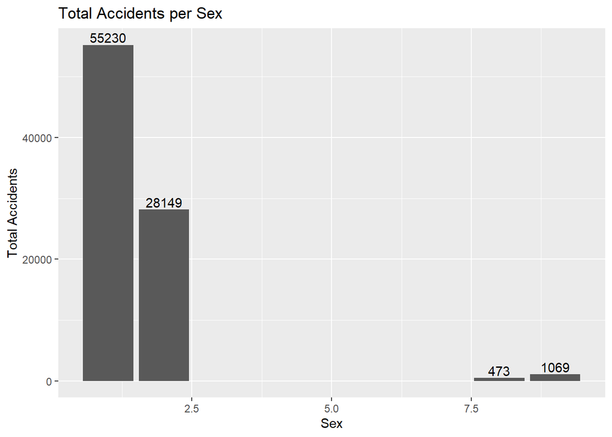

```r
p <- ggplot(df6, aes(x=SEX, y = count)) + geom_bar(stat="identity")+geom_text(aes(label = count), position = position_dodge(width = 0.9), vjust=-0.25)
p + ggtitle("Total Accidents per Sex")+ylab("Total Accidents")+xlab("Sex")
```

## Question 6

Now plot a choropleth map of the number of deaths on a county level. Also explain what you find.

```r
df11 <- df1 %>%
  group_by(COUNTY.x) %>%
  summarise(count = n())

df11
```

```
## # A tibble: 283 x 2
##    COUNTY.x count
##       <int> <int>
##  1        1   830
##  2        3   872
##  3        5   700
##  4        6    13
##  5        7   432
##  6        9   513
##  7       11   578
##  8       12    18
##  9       13   936
## 10       14     3
## # ... with 273 more rows
```

```r
county <- map_data('county')
head(county)
```

```
##        long      lat group order  region subregion
## 1 -86.50517 32.34920     1     1 alabama   autauga
## 2 -86.53382 32.35493     1     2 alabama   autauga
## 3 -86.54527 32.36639     1     3 alabama   autauga
## 4 -86.55673 32.37785     1     4 alabama   autauga
## 5 -86.57966 32.38357     1     5 alabama   autauga
## 6 -86.59111 32.37785     1     6 alabama   autauga
```

```r
GLC2 <- GLC %>%
  select(`County Code`, `County Name`) %>%
  distinct(`County Code`, `County Name`) %>%
  rename(COUNTY = `County Name`)%>%
  rename(COUNTY.x = `County Code`)

GLC2$subregion = tolower(GLC2$COUNTY)

GLC2
```

```
## # A tibble: 3,010 x 3
##    COUNTY.x COUNTY     subregion
##       <int> <chr>      <chr>
##  1       67 HENRY      henry
##  2       95 MARSHALL   marshall
##  3      123 TALLAPOOSA tallapoosa
##  4      107 PICKENS    pickens
##  5       39 COVINGTON  covington
##  6       77 LAUDERDALE lauderdale
##  7       15 CALHOUN    calhoun
##  8      109 PIKE       pike
##  9       83 LIMESTONE  limestone
## 10       73 JEFFERSON  jefferson
## # ... with 3,000 more rows
```

```r
joined4 <- inner_join(GLC2, df11, by = 'COUNTY.x')

joined5 <- inner_join(joined4,county, by = 'subregion')

joined5
```

```
## # A tibble: 374,810 x 9
##    COUNTY.x COUNTY subregion count  long   lat group order region
##       <int> <chr>  <chr>     <int> <dbl> <dbl> <dbl> <int> <chr>
##  1       67 HENRY  henry       517 -85.4  31.3    34  1585 alabama
##  2       67 HENRY  henry       517 -85.4  31.6    34  1586 alabama
##  3       67 HENRY  henry       517 -85.4  31.7    34  1587 alabama
##  4       67 HENRY  henry       517 -85.2  31.7    34  1588 alabama
##  5       67 HENRY  henry       517 -85.2  31.7    34  1589 alabama
##  6       67 HENRY  henry       517 -85.2  31.8    34  1590 alabama
##  7       67 HENRY  henry       517 -85.2  31.8    34  1591 alabama
##  8       67 HENRY  henry       517 -85.2  31.8    34  1592 alabama
##  9       67 HENRY  henry       517 -85.1  31.8    34  1593 alabama
## 10       67 HENRY  henry       517 -85.1  31.8    34  1594 alabama
## # ... with 374,800 more rows
```

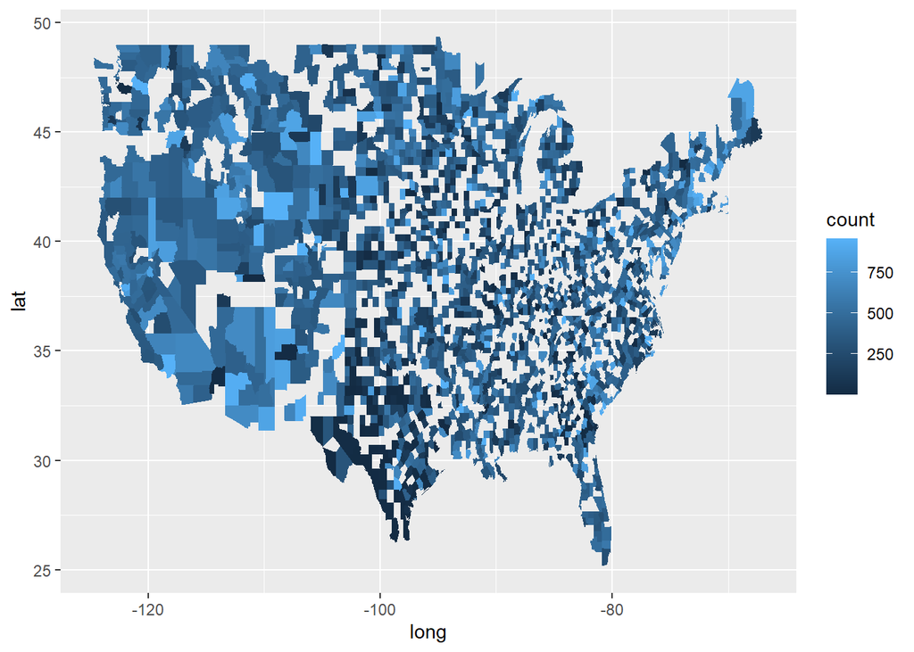

```r
b <- ggplot(joined5, aes(x=long, y=lat, group=group,fill=count))+geom_polygon()

b
```